# AGRRA 2017-2025 - cleaned

Molly Wilson

2026-04-17

# Site metadata

```r
site_depth <- read_excel(here("agrra_monitoring", "data_raw", "ATG_2017-2022", "Calculated", "Site", "Site.xlsx"), sheet = "Data") %>%
  clean_names() %>%
  filter(format(date, "%Y") >= 2017) %>%
  select(code, mean_depth)

sites_hist <- read_excel(here("agrra_monitoring", "data_raw", "ATG_2017-2022", "Raw", "MSAccess-Metadata.xlsx"), sheet = "Survey") %>%
  clean_names() %>%
  mutate(name = if_else(str_detect(name, "^Site \\d+"), # making NDNP site names consistent
                        str_extract(name, "^Site \\d+"),
                        name)) %>%
  select(site = name, t_benth_hist = benthic_transects, t_fish_hist = fish_transects)

sites_meta <- read_excel(here("agrra_monitoring", "data_raw", "ATG_NEMMA_2025", "Raw", "Metadata.xlsx"), sheet = "Survey") %>%
  mutate(zone = "NEMMA") %>%
  bind_rows(read_excel(here("agrra_monitoring", "data_raw", "ATG_NPA_2025", "Raw", "Metadata.xlsx"), sheet = "Survey") %>%
              mutate(zone = "NDNP")) %>%
  clean_names() %>%
  mutate(name = if_else(str_detect(name, "^Site \\d+"),
                        str_extract(name, "^Site \\d+"),
                        name),
         name = if_else(name == "Little Bird Patch", "Little Bird Backreef", name),
         code = str_replace_all(code, "\\s+", "")) %>%
  select(site = name, code, zone, latitude, longitude, t_benth_2025 = benthic_transects, t_fish_2025 = fish_transects) %>%
  left_join(sites_hist, by = "site") %>%
  left_join(site_depth, by = "code") %>%
  distinct() %>%
  filter(!is.na(t_benth_hist)) # removing sites with no historical data

write.csv(sites_meta, here("agrra_monitoring", "data_outputs", "sites_meta.csv"))
```

# Benthic

## Point cover and algal heights

Data overview:

- Need to work with transect-level data to get accurate standard deviations for dif. TA groupings
- 2017-2022: “BenthicPointCoverScaledByTransect.xlsx”
  - scaled to not include non-reef substrate
  - cover is in percent format (X/100)
  - TAS and TAM included but not STA
  - some transect numbers include surveyor initials
- 2025: “BenthicCoverScaledByTransect.xlsx”
  - scaled to not include non-reef substrate)
  - cover is in proportion format (X/1)
  - TAS/TAM/STA only included within tTA sheet (on “overall” sheet TA includes all forms of turf)
  - Little Bird Patch = Little Bird Backreef
- Here “TAS” will refer to TAS + TAM (+ STA in 2025)

```r
# define variables to include (removing CYAN for analyses)
benthic_var <- c("lc", "cca", "ta", "tas", "fma", "cma", "ainv", "peys")

benthic_cover_trans <-
  # historical data
  read_excel(here("agrra_monitoring", "data_raw", "ATG_2017-2022", "Calculated", "BenthicPointCoverScaled", "BenthicPointCoverScaledByTransect.xlsx"), sheet = "Data") %>%
  clean_names() %>%
  mutate(year = year(date),
         trans = as.character(trans), # to bind with 2025 NPA data that includes initials
         t_tas = tas + tam) %>%
  select(site, year, trans, benthic_var) %>%
  # bind 2025 data
  bind_rows(
    bind_rows(
      # 2025 NEMMA
      read_excel(here("agrra_monitoring", "data_raw", "ATG_NEMMA_2025", "Calculated", "BenthicCoverScaledByTransect.xlsx"), sheet = "Overall") %>%
        clean_names() %>%
        mutate(`transect_name` = as.character(`transect_name`)) %>%  # to bind with 2025 NPA data with initials
        # incorporate TA sheet
        left_join(read_excel(here("agrra_monitoring", "data_raw", "ATG_NEMMA_2025", "Calculated", "BenthicCoverScaledByTransect.xlsx"), sheet = "tTA") %>%
                    clean_names() %>%
                    select(transect_id, ta, sta, tas, tam)),
      # 2025 NDNP
      read_excel(here("agrra_monitoring", "data_raw", "ATG_NPA_2025", "Calculated", "BenthicCoverScaledByTransect.xlsx"), sheet = "Overall") %>%
        clean_names() %>%
        # incorporate TA sheet
        left_join(read_excel(here("agrra_monitoring", "data_raw", "ATG_NPA_2025", "Calculated", "BenthicCoverScaledByTransect.xlsx"), sheet = "tTA") %>%
                    clean_names() %>%
                    select(transect_id, ta, sta, tas, tam))) %>%
      mutate(year = 2025,
             survey_name = if_else(survey_name == "Little Bird Patch", "Little Bird Backreef", survey_name),
             tas_sum = tas + sta + tam) %>%
      select(site = survey_name, year, trans = transect_name, lc = t_coral, cca = t_cca, ta, tas = tas_sum, fma = t_fma, cma = t_cma, ainv = t_ainv, peys = t_pey)) %>%
  mutate(site = if_else(str_detect(site, "^Site \\d+"),
                        str_extract(site, "^Site \\d+"),
                        site)) %>% # dealing with NPA site name inconsistencies
  filter(year != 2022, # 2022 was incomplete data collection year for NPA
         site %in% sites_meta$site) %>%
  left_join(sites_meta %>% select(site, zone), by = "site") %>%
  # generating proportions with subset of benthic_var
  rowwise() %>%
  mutate(total = sum(c_across(all_of(benthic_var)), na.rm = TRUE)) %>%
  mutate(across(all_of(benthic_var), ~ (.x / total))) %>% # proportion format
  mutate(total = sum(c_across(all_of(benthic_var)), na.rm = TRUE)) %>% # test for total = 1
  ungroup()

benthic_cover_site <- benthic_cover_trans %>%
  group_by(site, zone, year) %>%
  rename_with(~ str_remove(.x, "t_")) %>%
  summarise(across(c(benthic_var),
                   list(mean = ~ mean(.x, na.rm = TRUE)),
                   .names = "{.col}_{.fn}")) %>%
  ungroup() %>%
  select(site, zone, year, ends_with("_mean")) %>%
  pivot_longer(cols = ends_with("_mean"),
    names_to = "var",
    values_to = "value") %>%
  mutate(metric = "benthic_cover",
         var = str_remove(var, "_mean"),
         unit = "proportion")

benthic_cover_year <- benthic_cover_site %>%
  group_by(year, zone, metric, unit, var) %>%
  summarise(mean = mean(value, na.rm = TRUE),
            sd   = sd(value, na.rm = TRUE),
            .groups = "drop")
```

## Algal height

```r
algal_height_site <- read_excel(here("agrra_monitoring", "data_raw", "ATG_2017-2022", "Calculated", "AlgaePointCoverScaled", "AlgaePointCoverScaledBySite.xlsx"), sheet = "Data") %>%
  rename_with(fix_names) %>%
  mutate(year = year(date)) %>%
  select(year, site, value = fh_avg) %>%
  bind_rows(read_excel(here("agrra_monitoring", "data_raw", "ATG_NEMMA_2025", "Calculated", "BenthicAlgalHeight.xlsx"), sheet = "Scaled") %>%
              bind_rows(read_excel(here("agrra_monitoring", "data_raw", "ATG_NPA_2025", "Calculated", "BenthicAlgalHeight.xlsx"), sheet = "Scaled")) %>%
              rename_with(fix_names) %>%
              mutate(year = 2025,
                     site = if_else(name == "Little Bird Patch", "Little Bird Backreef", name)) %>%
              select(year, site, value = 't_fma-h')) %>%
  mutate(site = if_else(str_detect(site, "^Site \\d+"),
                        str_extract(site, "^Site \\d+"),
                        site), # dealing with NPA sites name inconsistencies
         metric = "height",
         var = "fma_height",
         unit = "cm") %>%
  filter(site %in% sites_meta$site & year != 2022) %>%
  left_join(sites_meta %>% select(site, zone))
```

## Algal composition

```r
# metadata for genera - family matching
fma_key <- read_excel(here("agrra_monitoring", "data_raw", "ATG_NEMMA_2025", "Calculated", "BenthicCoverScaled.xlsx"), sheet = "Metadata") %>%
  clean_names() %>%
  fill(scaled_benthic_cover, column_header) %>%
  filter(str_starts(scaled_benthic_cover, "tFMA")) %>%
  select(code = column_header, genera = definition) %>%
  mutate(genera = if_else(code == "BFMA", "Other BFMA",
                          if_else(code == "GFMA", "Other GFMA",
                                  if_else(code == "RFMA", "Other RFMA",
                                          if_else(code == "FMA", "Other FMA", genera)))),
         code = tolower(code)) %>%
  rename(genus = genera)

# currently 2025 only
fma_gen_site <- read_excel(here("agrra_monitoring", "data_raw", "ATG_NEMMA_2025", "Calculated", "BenthicCoverScaled.xlsx"), sheet = "tFMA") %>%
  mutate(zone = "NEMMA") %>%
  bind_rows(read_excel(here("agrra_monitoring", "data_raw", "ATG_NPA_2025", "Calculated", "BenthicCoverScaled.xlsx"), sheet = "tFMA") %>%
              mutate(zone = "NDNP")) %>%
  rename_with(fix_names) %>%
  mutate(year = 2025,
         site = if_else(name == "Little Bird Patch", "Little Bird Backreef", name)) %>%
  select(year, zone, site, contains("avg"), fma_tot_avg = t_fma_avg) %>% # otherwise tFMA and (other) FMA columns get duplicated as FMA
  rename_with(~ str_remove(.x, "_avg")) %>%
  pivot_longer(cols = -c(year, zone, site, fma_tot),
               names_to = "code",
               values_to = "percent_cover") %>%
  filter(fma_tot > 0) %>%
  mutate(prop_cover = percent_cover / fma_tot) %>%
  left_join(fma_key, by = "code") %>%
  select(year, zone, site, code, genus, percent_cover, prop_cover) %>%
  filter(!is.na(genus))

fma_gen_year <- fma_gen_site %>%
  group_by(year, zone, genus) %>%
  summarize(mean_perc_cov = mean(percent_cover),
            sd_perc_cov = sd(percent_cover),
            mean_prop_cov = mean(prop_cover),
            sd_prop_cov = sd(prop_cover)) %>%
  filter(mean_perc_cov > 0)

kable(fma_gen_year %>% filter(genus == "Dictyota"))
```

| year | zone | genus | mean_perc_cov | sd_perc_cov | mean_prop_cov | sd_prop_cov |
| --- | --- | --- | --- | --- | --- | --- |
| 2025 | NDNP | Dictyota | 0.2922724 | 0.0835043 | 0.9061782 | 0.1032620 |
| 2025 | NEMMA | Dictyota | 0.3851722 | 0.1641809 | 0.9170544 | 0.1351368 |

## Coral composition

Data overview:

- Due to high UNKN in 2019 NDNP data, family-level assessments will only include NEMMA sites
- Extremely complicated and inconsistent data structures to work with - wrote functions for cleaning headers and created meta file to link codes to species and families consistently across years

```r
# metadata for species - family matching
coral_meta <- read_excel(here("agrra_monitoring", "data_raw", "ATG_NEMMA_2025", "Calculated", "BenthicCoralCoverScaled.xlsx"), sheet = "Metadata") %>%
  clean_names() %>%
  fill(scaled_coral_cover, column_header)

coral_meta_fam <- coral_meta %>%
  filter(str_starts(column_header, "t") | column_header == "UNKN") %>%
  select(family_code = column_header, family = definition) %>%
  mutate(family = gsub("\\s*\\([^\\)]+\\)", "", family)) %>% # removing fluff
  distinct() # removing UNKN duplicate

coral_meta_spp <- coral_meta %>%
  filter(str_starts(scaled_coral_cover, "t") | scaled_coral_cover == "UNKN") %>%
  select(species_code = column_header, family_code = scaled_coral_cover, species = definition) %>%
  left_join(coral_meta_fam, by = "family_code") %>%
  mutate(genus = sub(" .*", "", species),
         family_code = str_remove(family_code, "^t"),
         across(c(species, family), ~ str_replace(., "Unknown sp. of Live Coral", "Unknown spp.")),
         family = if_else(family == "Scleractinia incertae sedis", "Unknown spp.", family))

# historical data
coral_spp_hist <- read_excel(here("agrra_monitoring", "data_raw", "ATG_2017-2022", "Calculated", "CoralCoverSpeciesScaled", "CoralCoverSpeciesScaledBySite.xlsx"), sheet = "Data") %>%
  rename_with(fix_names) %>%
  mutate(year = year(date)) %>%
  filter(year %in% c(2017, 2019)) %>% # 2022 was incomplete NPA year
  pivot_longer(
    cols = matches("^[a-z]{4}_(avg|std)$"),   # all columns like acer_ave, apal_std, etc.
    names_to = c("species_code", ".value"),        # split into species and measurement type
    names_sep = "_"
  ) %>%
  mutate(across(c(avg, std), ~ .x / 100)) %>% # to match 2025 format (fraction of 1)
  select(site, year, species_code, avg, std)

# 2025 data
file_coral_nemma <- here("agrra_monitoring", "data_raw", "ATG_NEMMA_2025", "Calculated", "BenthicCoralCoverScaled.xlsx")
file_coral_npa <- here("agrra_monitoring", "data_raw", "ATG_NPA_2025", "Calculated", "BenthicCoralCoverScaled.xlsx")

clean_excel_coral <- function(file_path) {
  sheets <- excel_sheets(file_path)
  sheets_to_join <- setdiff(sheets, c("TermsOfUse", "Metadata", "Overall"))  # exclude

  sheets_list <- map(sheets_to_join, ~ read_excel(file_path, sheet = .x) %>%
                       rename_with(~ gsub("^(t)([A-Za-z]{4})(avg|med|std)$", "\\1_\\2_\\3", .x, ignore.case = TRUE)) %>%
                       rename_with(~ gsub("([A-Za-z]{4})(avg|med|std)$", "\\1_\\2", .x, ignore.case = TRUE)) %>%
                       clean_names())

  reduce(sheets_list, left_join, by = c("survey_id", "code", "name", "nt"))
}

coral_spp_2025 <- clean_excel_coral(file_coral_npa) %>%
  bind_rows(clean_excel_coral(file_coral_nemma)) %>%
  mutate(year = 2025) %>%
  rename(site = name) %>%
  pivot_longer(
    cols = matches("^[a-z]{4}_(avg|std)$"),   # all columns like acer_ave, apal_std, etc.
    names_to = c("species_code", ".value"),        # split into species and measurement type
    names_sep = "_"
  ) %>%
  select(site, year, species_code, avg, std)

# merge for complete df
coral_spp_site <- bind_rows(coral_spp_hist, coral_spp_2025) %>%
  mutate(zone = if_else(str_detect(site, "^Site \\d+"), "NDNP",
                            if_else(str_detect(site, "Redonda"), "Redonda",
                                    "NEMMA")),
         site = if_else(str_detect(site, "^Site \\d+"),
                        str_extract(site, "^Site \\d+"),
                        site)) %>%
  mutate(species_code = toupper(species_code),
         site = if_else(site == "Little Bird Patch", "Little Bird Backreef", site)) %>%
  left_join(coral_meta_spp, by = "species_code")  %>%
  group_by(site) %>%
  filter(n_distinct(year) > 1) %>% # only keeping sites with over time comparisons
  ungroup()

coral_fam_site <- coral_spp_site %>%
  group_by(year, zone, site, family) %>%
  summarize(value = sum(avg, na.rm = TRUE)) %>%
  ungroup()

coral_fam_year <- coral_fam_site %>%
  group_by(year, zone, site) %>%
  complete( # adding 0s for when nothing was present
    family = unique(coral_spp_site$family),
    fill = list(avg = 0)
  ) %>%
  ungroup() %>%
  group_by(year, zone, family) %>%
  summarize(mean = mean(value, na.rm = TRUE),
         sd = sd(value, na.rm = TRUE)) %>%
  ungroup() %>%
  group_by(year, zone) %>%
  mutate(rel_mean = mean / sum(mean, na.rm = TRUE)) %>%
  ungroup()

chk <- coral_fam_year %>%
  group_by(year, zone) %>%
  summarize(tot = sum(rel_mean, na.rm = TRUE))
kable(coral_fam_year)
```

| year | zone | family | mean | sd | rel_mean |
| --- | --- | --- | --- | --- | --- |
| 2017 | NEMMA | Acroporidae | 0.0321500 | 0.0472337 | 0.2679111 |
| 2017 | NEMMA | Agariciidae | 0.0033850 | 0.0040209 | 0.0282077 |
| 2017 | NEMMA | Astrocoeniidae | 0.0000000 | 0.0000000 | 0.0000000 |
| 2017 | NEMMA | Faviidae | 0.0082188 | 0.0046564 | 0.0684882 |
| 2017 | NEMMA | Meandrinidae | 0.0000000 | 0.0000000 | 0.0000000 |
| 2017 | NEMMA | Merulinidae | 0.0194700 | 0.0267375 | 0.1622466 |
| 2017 | NEMMA | Milleporidae | 0.0120238 | 0.0171545 | 0.1001958 |
| 2017 | NEMMA | Montastraeidae | 0.0004062 | 0.0007594 | 0.0033853 |
| 2017 | NEMMA | Oculinidae | 0.0000000 | 0.0000000 | 0.0000000 |
| 2017 | NEMMA | Pocilloporidae | 0.0000000 | 0.0000000 | 0.0000000 |
| 2017 | NEMMA | Poritidae | 0.0352488 | 0.0199039 | 0.2937335 |
| 2017 | NEMMA | Siderastreidae | 0.0027487 | 0.0019945 | 0.0229058 |
| 2017 | NEMMA | Unknown spp. | 0.0063512 | 0.0042845 | 0.0529260 |
| 2019 | NDNP | Acroporidae | 0.0003614 | 0.0009708 | 0.0064196 |
| 2019 | NDNP | Agariciidae | 0.0006607 | 0.0016107 | 0.0117355 |
| 2019 | NDNP | Astrocoeniidae | 0.0006136 | 0.0008548 | 0.0108981 |
| 2019 | NDNP | Faviidae | 0.0042729 | 0.0026645 | 0.0758935 |
| 2019 | NDNP | Meandrinidae | 0.0001193 | 0.0004463 | 0.0021187 |
| 2019 | NDNP | Merulinidae | 0.0015043 | 0.0023375 | 0.0267188 |
| 2019 | NDNP | Milleporidae | 0.0057000 | 0.0046027 | 0.1012421 |
| 2019 | NDNP | Montastraeidae | 0.0024743 | 0.0032912 | 0.0439477 |
| 2019 | NDNP | Oculinidae | 0.0000000 | 0.0000000 | 0.0000000 |
| 2019 | NDNP | Pocilloporidae | 0.0000000 | 0.0000000 | 0.0000000 |
| 2019 | NDNP | Poritidae | 0.0077107 | 0.0056531 | 0.1369559 |
| 2019 | NDNP | Siderastreidae | 0.0072879 | 0.0052044 | 0.1294452 |
| 2019 | NDNP | Unknown spp. | 0.0255957 | 0.0091073 | 0.4546250 |
| 2025 | NDNP | Acroporidae | 0.0000000 | 0.0000000 | 0.0000000 |
| 2025 | NDNP | Agariciidae | 0.0000000 | 0.0000000 | 0.0000000 |
| 2025 | NDNP | Astrocoeniidae | 0.0000000 | 0.0000000 | 0.0000000 |
| 2025 | NDNP | Faviidae | 0.0036593 | 0.0038392 | 0.1363491 |
| 2025 | NDNP | Meandrinidae | 0.0000000 | 0.0000000 | 0.0000000 |
| 2025 | NDNP | Merulinidae | 0.0004762 | 0.0010187 | 0.0177434 |
| 2025 | NDNP | Milleporidae | 0.0068143 | 0.0053052 | 0.2539080 |
| 2025 | NDNP | Montastraeidae | 0.0013429 | 0.0019024 | 0.0500363 |
| 2025 | NDNP | Oculinidae | 0.0000000 | 0.0000000 | 0.0000000 |
| 2025 | NDNP | Pocilloporidae | 0.0004798 | 0.0013884 | 0.0178765 |
| 2025 | NDNP | Poritidae | 0.0040967 | 0.0049037 | 0.1526464 |
| 2025 | NDNP | Siderastreidae | 0.0054495 | 0.0033371 | 0.2030554 |
| 2025 | NDNP | Unknown spp. | 0.0045190 | 0.0068499 | 0.1683848 |
| 2025 | NEMMA | Acroporidae | 0.0033333 | 0.0094281 | 0.0788177 |
| 2025 | NEMMA | Agariciidae | 0.0006250 | 0.0012400 | 0.0147783 |
| 2025 | NEMMA | Astrocoeniidae | 0.0002083 | 0.0005893 | 0.0049261 |
| 2025 | NEMMA | Faviidae | 0.0045979 | 0.0037457 | 0.1087192 |
| 2025 | NEMMA | Meandrinidae | 0.0000000 | 0.0000000 | 0.0000000 |
| 2025 | NEMMA | Merulinidae | 0.0163688 | 0.0184164 | 0.3870444 |
| 2025 | NEMMA | Milleporidae | 0.0014625 | 0.0024398 | 0.0345813 |
| 2025 | NEMMA | Montastraeidae | 0.0000000 | 0.0000000 | 0.0000000 |
| 2025 | NEMMA | Oculinidae | 0.0000000 | 0.0000000 | 0.0000000 |
| 2025 | NEMMA | Pocilloporidae | 0.0000000 | 0.0000000 | 0.0000000 |
| 2025 | NEMMA | Poritidae | 0.0110521 | 0.0085802 | 0.2613301 |
| 2025 | NEMMA | Siderastreidae | 0.0046437 | 0.0065089 | 0.1098029 |
| 2025 | NEMMA | Unknown spp. | 0.0000000 | 0.0000000 | 0.0000000 |

```r
coral_fam_ttests <- coral_fam_site %>%
  group_by(zone, family) %>%
  wilcox_test(value ~ year,
              paired = TRUE)
kable(coral_fam_ttests)
```

| zone | family | .y. | group1 | group2 | n1 | n2 | statistic | p | p.adj | p.adj.signif |
| --- | --- | --- | --- | --- | --- | --- | --- | --- | --- | --- |
| NDNP | Acroporidae | value | 2019 | 2025 | 14 | 14 | 3 | 0.371 | 0.371 | ns |
| NDNP | Agariciidae | value | 2019 | 2025 | 14 | 14 | 6 | 0.181 | 0.181 | ns |
| NDNP | Astrocoeniidae | value | 2019 | 2025 | 14 | 14 | 15 | 0.058 | 0.058 | ns |
| NDNP | Faviidae | value | 2019 | 2025 | 14 | 14 | 67 | 0.391 | 0.391 | ns |
| NDNP | Meandrinidae | value | 2019 | 2025 | 14 | 14 | 1 | 1.000 | 1.000 | ns |
| NDNP | Merulinidae | value | 2019 | 2025 | 14 | 14 | 36 | 0.123 | 0.123 | ns |
| NDNP | Milleporidae | value | 2019 | 2025 | 14 | 14 | 42 | 0.834 | 0.834 | ns |
| NDNP | Montastraeidae | value | 2019 | 2025 | 14 | 14 | 44 | 0.351 | 0.351 | ns |
| NDNP | Oculinidae | value | 2019 | 2025 | 14 | 14 | 0 | NaN | NaN |  |
| NDNP | Pocilloporidae | value | 2019 | 2025 | 14 | 14 | 0 | 0.371 | 0.371 | ns |
| NDNP | Poritidae | value | 2019 | 2025 | 14 | 14 | 75 | 0.173 | 0.173 | ns |
| NDNP | Siderastreidae | value | 2019 | 2025 | 14 | 14 | 61 | 0.626 | 0.626 | ns |
| NDNP | Unknown spp. | value | 2019 | 2025 | 14 | 14 | 105 | 0.001 | 0.001 | ** |
| NEMMA | Acroporidae | value | 2017 | 2025 | 8 | 8 | 15 | 0.059 | 0.059 | ns |
| NEMMA | Agariciidae | value | 2017 | 2025 | 8 | 8 | 19 | 0.094 | 0.094 | ns |
| NEMMA | Astrocoeniidae | value | 2017 | 2025 | 8 | 8 | 0 | 1.000 | 1.000 | ns |
| NEMMA | Faviidae | value | 2017 | 2025 | 8 | 8 | 29 | 0.148 | 0.148 | ns |
| NEMMA | Meandrinidae | value | 2017 | 2025 | 8 | 8 | 0 | NaN | NaN |  |
| NEMMA | Merulinidae | value | 2017 | 2025 | 8 | 8 | 23 | 0.547 | 0.547 | ns |
| NEMMA | Milleporidae | value | 2017 | 2025 | 8 | 8 | 15 | 0.059 | 0.059 | ns |
| NEMMA | Montastraeidae | value | 2017 | 2025 | 8 | 8 | 3 | 0.371 | 0.371 | ns |
| NEMMA | Oculinidae | value | 2017 | 2025 | 8 | 8 | 0 | NaN | NaN |  |
| NEMMA | Pocilloporidae | value | 2017 | 2025 | 8 | 8 | 0 | NaN | NaN |  |
| NEMMA | Poritidae | value | 2017 | 2025 | 8 | 8 | 34 | 0.023 | 0.023 | * |
| NEMMA | Siderastreidae | value | 2017 | 2025 | 8 | 8 | 21 | 0.742 | 0.742 | ns |
| NEMMA | Unknown spp. | value | 2017 | 2025 | 8 | 8 | 28 | 0.022 | 0.022 | * |

```r
# select primary families for plots
coral_fams <- c("Acroporidae", "Faviidae", "Merulinidae", "Milleporidae", "Montastraeidae",  "Poritidae", "Siderastreidae") #"Unknown spp."
```

### Delta plots

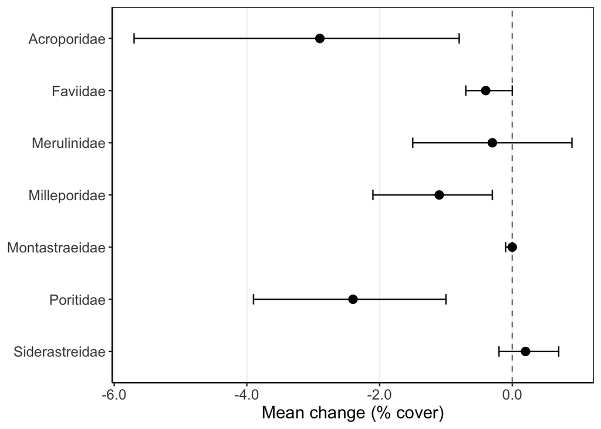

```r
boot_mean_ci <- function(x, n_boot = 1000, conf = 0.95) { # compute bootstrapped mean CI
  # Boot function
  boot_fn <- function(data, indices) mean(data[indices])

  b <- boot::boot(x, statistic = boot_fn, R = n_boot)

  ci <- boot::boot.ci(b, type = "perc")$percent[4:5]  # lower, upper
  return(ci)
}

coral_delta_table <- coral_fam_site %>%
  filter(zone == "NEMMA", year %in% c(2017, 2025), family %in% coral_fams) %>%
  select(year, site, family, value) %>%
  # Pivot so each row is a site × family, with 2017 and 2025 in separate columns
  tidyr::pivot_wider(
    names_from = year,
    values_from = value,
    names_prefix = "yr_"
  ) %>%
  # Keep only sites that have data for both years
  filter(!is.na(yr_2017) & !is.na(yr_2025)) %>%
  # Calculate delta per site
  mutate(delta = yr_2025 - yr_2017) %>%
  group_by(family) %>%
  summarise(
    mean_delta = mean(delta, na.rm = TRUE),
    ci = list(if(length(unique(delta)) > 1) boot_mean_ci(delta) else c(NA, NA)),
    wilcox_p = if(length(unique(delta)) > 1) wilcox.test(delta, mu = 0)$p.value else NA,
    .groups = "drop"
  ) %>%
  mutate(
    ci_lower = sapply(ci, `[[`, 1),
    ci_upper = sapply(ci, `[[`, 2)
  ) %>%
  select(-ci) %>%
  mutate(
    mean_delta = round(mean_delta, 3),
    ci_lower = round(ci_lower, 3),
    ci_upper = round(ci_upper, 3),
    wilcox_p = signif(wilcox_p, 3)
  ) %>%
  arrange(family)

p_delta_coral <- ggplot(coral_delta_table,
                        aes(x = mean_delta, y = forcats::fct_rev(family))) +
  geom_vline(xintercept = 0, linetype = "dashed", color = "grey50") +
  geom_errorbarh(aes(xmin = ci_lower, xmax = ci_upper), height = 0.2) +
  geom_point(size = 3) +
  labs(
    x = "Mean change (% cover)",
    y = NULL,
    title = NULL
  ) +
  # scale_x_continuous(labels = label_percent(accuracy = 0.1)) +
  scale_x_continuous(labels = function(x) sprintf("%.1f", x * 100)) +
  theme_pub() +
  theme(panel.grid.major.x = element_line(color = "grey95"))

p_delta_coral
```

### Heat plots

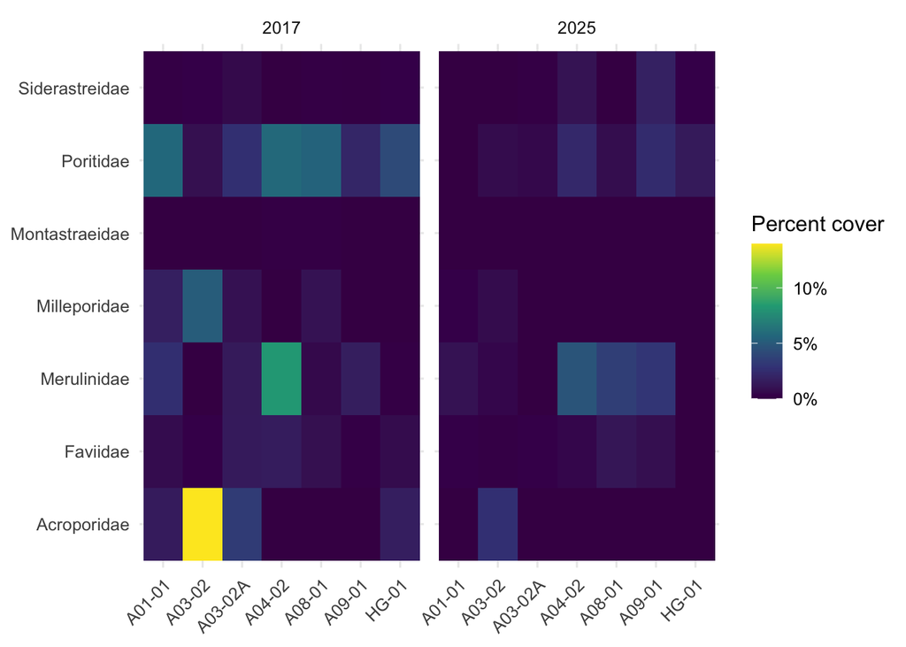

```r
ggplot(coral_fam_site %>%
         filter(zone == "NEMMA" & family %in% c(coral_fams)) %>%
         left_join(sites_meta %>% select(site, code)),
       aes(code, family, fill = value)) +
  geom_tile() +
  facet_wrap(~year) +
  scale_fill_viridis_c(labels = percent,
                       name = "Percent cover") +
  labs(x = NULL,
       y = NULL,
       fill = "Percent cover") +
  theme_minimal(base_size = 12) +
  theme(axis.text.x = element_text(angle = 45, hjust = 1))
```

```r
ggsave(here(fig_dir, "coral_fam_heat.png"), width = 8, height = 5)
```

## Coral recruits

Data overview:

- Historical: CoralRecruitsBySite.xlsx
  - family level
  - remove “DICH” code (not in 2025 classifications, not present in either dataset)
  - missing many families present in 2025 (e.g., ACRO, MERU)
- 2025: BenthicCoralRecruis.xlxs
  - genus and species level
  - missing site-level standard deviation in data

```r
# using coral_meta_spp key generated in prev. section

# historical data

recruits_hist_sized <- read_excel(here("agrra_monitoring", "data_raw", "ATG_2017-2022", "Calculated", "CoralRecruits", "CoralRecruitsBySite.xlsx"), sheet = "Small") %>%
  mutate (size = "small") %>%
  rbind(read_excel(here("agrra_monitoring", "data_raw", "ATG_2017-2022", "Calculated", "CoralRecruits", "CoralRecruitsBySite.xlsx"), sheet = "Large") %>%
          mutate (size = "large")) %>%
  rename_with(fix_names) %>%
  mutate(year = year(date)) %>%
  filter(year %in% c(2017, 2019)) %>% # 2022 was incomplete NPA year
  pivot_longer(
    cols = matches(".*_(avg|std)$"),   # all columns ending in avg or std
    names_to = c("family_code", ".value"),        # split into species and measurement type
    names_sep = "_"
  ) %>%
  select(site, year, family_code, size, avg)

recruits_hist_tot <- recruits_hist_sized %>%
  group_by(site, year, family_code) %>%
  summarize(
    avg = sum(avg, na.rm = TRUE),
    .groups = "drop"
  ) %>%
  mutate(size = "total") %>%
  select(site, year, family_code, size, avg)
recruits_hist <- bind_rows(recruits_hist_tot, recruits_hist_sized)

# 2025 data

recruits_2025 <- read_excel(here("agrra_monitoring", "data_raw", "ATG_NEMMA_2025", "Calculated", "BenthicCoralRecruits.xlsx"), sheet = "Overall") %>%
  bind_rows(read_excel(here("agrra_monitoring", "data_raw", "ATG_NPA_2025", "Calculated", "BenthicCoralRecruits.xlsx"), sheet = "Overall")) %>%
  rename_with(fix_names) %>%
  mutate(year = 2025) %>%
  rename(site = name) %>%
  select(year, site, matches("_(small|large|total)$")) %>%
  pivot_longer(
    cols = matches("_(small|large|total)$"),
    names_to = c("family_code", "size"),
    names_pattern = "^(.*?)_(small|large|total)$",
    values_to = "avg"
  ) %>%
  select(site, year, family_code, size, avg) %>%
  mutate(family_code = str_remove(family_code, "^t_"))
# no SD for 2025

test <- recruits_2025 %>%
  distinct(family_code, size) %>%
  anti_join(
    recruits_hist %>%
      distinct(family_code, size),
    by = c("family_code", "size")
  )

# merge for complete df
recruits_fam_site <- bind_rows(recruits_hist, recruits_2025) %>%
  mutate(zone = if_else(str_detect(site, "^Site \\d+"), "NDNP",
                            if_else(str_detect(site, "Redonda"), "Redonda",
                                    "NEMMA")),
         site = if_else(str_detect(site, "^Site \\d+"),
                        str_extract(site, "^Site \\d+"),
                        site),
         site = if_else(site == "Little Bird Patch", "Little Bird Backreef", site),
         family_code = toupper(family_code)) %>%
  filter(family_code != "DICH") %>% # in historical data only, none present
  # only keeping sites with over time comparisons
  group_by(site) %>%
  filter(n_distinct(year) > 1) %>%
  ungroup() %>%
  # adding 0s for missing data
  complete(nesting(site, year, zone),
           family_code,
           size,
           fill = list(avg = 0)) %>%
  distinct() %>%
  # joining family names
  left_join(coral_meta_spp %>%
              select(family_code, family) %>%
              distinct(),
            by = "family_code") %>%
  mutate(family = if_else(family_code == "ALL", "All species",
                          if_else(family_code == "CARB", "Unknown spp.", family)))

recruits_fam_year <- recruits_fam_site %>%
  group_by(year, zone, family_code, family, size) %>%
  summarize(mean = mean(avg), # 0s already included for absent families
            sd = sd(avg)) %>%
  group_by(year, zone) %>%
  mutate(rel_mean = mean / sum(mean))
# kable(recruits_fam_year)
#
# recruits_fam_ttests <- recruits_fam_site %>%
#   group_by(zone, family, family_code, size) %>%
#   wilcox_test(avg ~ year,
#               paired = TRUE)
# kable(recruits_fam_ttests)
```

## Diadema

Data overview: - 2025: MotileInverts.xlsx - 2017-2019: MotileInvertsBySite.xlsx

```r
diadema <- read_excel(here("agrra_monitoring", "data_raw", "ATG_2017-2022", "Calculated", "MotileInverts", "MotileInvertsBySite.xlsx"), sheet = "Data") %>%
  rename_with(fix_names) %>%
  mutate(year = year(date)) %>%
  select(site, year, matches("^dt_|^da_|^dj_")) %>%
  rbind(read_excel(here("agrra_monitoring", "data_raw", "ATG_NEMMA_2025", "Calculated", "MotileInverts.xlsx"), sheet = "Overall") %>%
          rbind(read_excel(here("agrra_monitoring", "data_raw", "ATG_NPA_2025", "Calculated", "MotileInverts.xlsx"), sheet = "Overall")) %>%
          rename_with(fix_names) %>%
          mutate(year = 2025,
                 name = if_else(name == "Little Bird Patch", "Little Bird Backreef", name)) %>%
          select(site = name, year, matches("^dt_|^da_|^dj_"), -ends_with("_med"))) %>%
  filter(year != 2022) %>% # incomplete year for NPA
  mutate(site = if_else(str_detect(site, "^Site \\d+"),
                        str_extract(site, "^Site \\d+"),
                        site)) %>%
  filter(site %in% sites_meta$site) %>%
  left_join(sites_meta %>% select(site, zone)) %>%
  group_by(site) %>%
  filter(n_distinct(year) > 1) %>% # only keeping sites with over time comparisons
  ungroup()

diadema_site <- diadema %>%
  select(zone, site, year, dt_avg, da_avg, dj_avg) %>%  # keep density columns
  pivot_longer(
    cols = c(dt_avg, da_avg, dj_avg),
    names_to = "var",
    values_to = "value"
  ) %>%
  mutate(metric = "diadema_density",
         unit = "g_m2",
         var = recode(var,
                        dt_avg = "total",
                        da_avg = "adult",
                        dj_avg = "juvenile"))

diadema_year <- diadema_site %>%
  group_by(zone, year, metric, unit, var) %>%
  summarise(mean = mean(value, na.rm = TRUE),
            sd   = sd(value, na.rm = TRUE),
            .groups = "drop")

diadema_tests <- diadema_site %>%
  mutate(period = if_else(year == 2025, "y2025", "hist")) %>%
  select(site, zone, var, period, value) %>%
  pivot_wider(names_from = period,
              values_from = value) %>%
  group_by(zone, var) %>%
  summarise(p = wilcox.test(hist, y2025, paired = TRUE, exact = FALSE)$p.value,
    .groups = "drop")
```

# Fish

## Biomass

Data overview:

- 2017: FishBiomassByTransect.xlsx
  - “Data” sheet has transect-level data by family and group
  - Ignoring “group” classifications here as it isn’t consistent with 2025
- 2025: FishBiomassByTransect.xlsx
  - “Overall” sheet has transect-level data by family
  - Family sheets have transect-level data by species
- Converting all data to kg/100m2

```r
# create compatible family key by merging metadata
fish_fam_key <- full_join(
  read_excel(here("agrra_monitoring", "data_raw", "ATG_2017-2022", "Calculated", "FishBiomass", "FishBiomassBySite.xlsx"), sheet = "Key") %>%
    clean_names() %>%
    slice(21:40) %>%
    select(code_com = 1,
           definition = 2) %>%
    mutate(family = str_remove(word(definition, 1), ":"),
           family = if_else(family == "Wrasse", "Wrasses",
                            if_else(code_com == "PUFF", "Pufferfishes", family))) %>%
    select(-definition),
  read_excel(here("agrra_monitoring", "data_raw", "ATG_NEMMA_2025", "Calculated", "FishBiomass.xlsx"), sheet = "Metadata") %>%
    clean_names() %>%
    slice(23:42) %>%
    select(code_lat = 2,
           definition = 3) %>%
    mutate(family = str_remove(word(definition, 1), ":")) %>%
    select(-definition),
  by = "family") %>%
  mutate(code_lat = tolower(gsub("^t", "", code_lat)),
         code_com = tolower(code_com)) %>%
  select(code_com, code_lat, family) %>%
  bind_rows(
    tibble(code_com = "t",
           code_lat = "all",
           family   = "Total")) %>%
  pivot_longer(cols = c(code_com, code_lat),
               names_to = "code_type",
               values_to = "code")

fish_bm_fam_site <- bind_rows(
  # historical data
  read_excel(here("agrra_monitoring", "data_raw", "ATG_2017-2022",
                  "Calculated", "FishBiomass", "FishBiomassBySite.xlsx"),
             sheet = "Data") %>%
    rename_with(fix_names) %>%
    mutate(code_type = "code_com",
             year = year(date)),
  # 2025 data
  rbind(read_excel(here("agrra_monitoring", "data_raw", "ATG_NEMMA_2025",
                    "Calculated", "FishBiomass.xlsx"),
               sheet = "Overall"),
        read_excel(here("agrra_monitoring", "data_raw", "ATG_NPA_2025",
                    "Calculated", "FishBiomass.xlsx"),
               sheet = "Overall")) %>%
    rename_with(fix_names) %>%
    mutate(year = 2025,
           site = if_else(name == "Little Bird Patch",
                          "Little Bird Backreef",
                          name),
           code_type = "code_lat") %>%
    rename_with(~ gsub("^t_", "", .x), .cols = contains("avg"))
) %>%
  # wrangle data
  ## min n transect = 8 in both years
  group_by(site) %>%
  filter(all(nt >= 8)) %>%
  ungroup() %>%
  mutate(site = if_else(str_detect(site, "^Site \\d+"), str_extract(site, "^Site \\d+"), site),
         if_else(name == "Little Bird Patch", "Little Bird Backreef", name)) %>%
  select(site, year, code_type, contains("avg")) %>%
  pivot_longer(cols = contains("avg"),
               names_to = "family_stat",
               values_to = "value") %>%
  separate(family_stat,
           into = c("code", "stat"),
           sep = "_(?=[^_]+$)") %>%
  # merge with family key
  left_join(fish_fam_key, by = c("code_type", "code")) %>%
  left_join(sites_meta %>% select(site, zone)) %>%
  mutate(value = value/1000, # converting from g to kg
         metric = "fish_biomass",
         unit = "kg_100m2") %>%
  filter(site %in% sites_meta$site,
         year != 2022, # incomplete NDNP year
         !is.na(family)) %>% # historical groupings excluded from key
  select(site, zone, year, metric, var = family, value, unit)

herb_bm_site <- fish_bm_fam_site %>%
  filter(var %in% c("Parrotfishes", "Surgeonfishes")) %>%
  group_by(site, zone, year, metric, unit) %>%
  summarise(value = sum(value, na.rm = TRUE),
    .groups = "drop") %>%
  mutate(var = "Herbivores") %>%
  select(site, zone, year, metric, var, value, unit)

fish_bm_site <- rbind(fish_bm_fam_site, herb_bm_site) %>%
  filter(var %in% c("Total", "Herbivores"))

fish_bm_year <- fish_bm_site %>%
  group_by(year, zone, metric, var, unit) %>%
  summarize(mean = mean(value),
            sd = sd(value))
```

# Summary dfs

```r
sum_site_yr <- bind_rows(benthic_cover_site, algal_height_site, diadema_site, fish_bm_site) %>%
  mutate(var = tolower(var))

# create explicit paired site-level dataset
sum_site_pairs <- sum_site_yr %>%
  mutate(period = if_else(year == 2025, "2025", "hist")) %>%
  select(site, zone, metric, var, unit, period, value) %>%
  pivot_wider(
    names_from = period,
    values_from = value
  ) %>%
  filter(!is.na(hist) & !is.na(`2025`)) %>%
  mutate(site_delta = `2025` - hist)

options(scipen = 999) # avoid scientific notation in printing values

# create zone-level summary
sum_zone <- sum_site_pairs %>%
  group_by(zone, metric, var, unit) %>%
  summarise(mean_hist = mean(hist, na.rm = TRUE),
            sd_hist   = sd(hist, na.rm = TRUE),
            mean_2025 = mean(`2025`, na.rm = TRUE),
            sd_2025   = sd(`2025`, na.rm = TRUE),
            pct_change = ((mean(`2025`, na.rm = TRUE) -
                             mean(hist, na.rm = TRUE)) /
                            mean(hist, na.rm = TRUE)) * 100,
            delta = mean(site_delta, na.rm = TRUE),
            CI = list(
              quantile(
                replicate(
                  5000,
                  mean(sample(site_delta,
                              replace = TRUE),
                       na.rm = TRUE)),
                probs = c(0.025, 0.975),
                na.rm = TRUE)),
            p = suppressWarnings(
              wilcox.test(
                hist,
                `2025`,
                paired = TRUE,
                exact = FALSE
              )$p.value
            ),
            .groups = "drop") %>%
  mutate(metric_pub = str_to_sentence(gsub("_", " ", metric)),
         CI_low  = map_dbl(CI, 1),
         CI_high = map_dbl(CI, 2),
         var_pub = recode(var,
                          lc   = "Live coral",
                          cca  = "CCA",
                          ta   = "Turf algae",
                          tas  = "Turf-sediment complex",
                          fma  = "Fleshy macroalgae",
                          cma  = "Calc. macroalgae",
                          ainv = "Aggressive inverts",
                          peys = "Peysonnelids",
                          fma_height = "Fleshy macroalgal height",
                          .default = str_to_title(var)
         )) %>%
  select(-CI) %>%
  rstatix::add_significance(p.col = "p") %>%
  rename(p_label = p.signif) %>%
  select(zone, metric, metric_pub, var, var_pub, unit, everything())

sum_zone_pub <- sum_zone %>%
  select(-metric, -var) %>%
  unite(variable, metric_pub, var_pub, sep = " - ", remove = TRUE)
kable(sum_zone_pub)
```

| zone | variable | unit | mean_hist | sd_hist | mean_2025 | sd_2025 | pct_change | delta | p | CI_low | CI_high | p_label |
| --- | --- | --- | --- | --- | --- | --- | --- | --- | --- | --- | --- | --- |
| NDNP | Benthic cover - Aggressive inverts | proportion | 0.0310022 | 0.0181750 | 0.0198373 | 0.0105945 | -36.0132059 | -0.0111649 | 0.1487786 | -0.0235007 | 0.0013182 | ns |
| NDNP | Benthic cover - CCA | proportion | 0.0361416 | 0.0254095 | 0.0460322 | 0.0548308 | 27.3665080 | 0.0098907 | 0.5720817 | -0.0066381 | 0.0312926 | ns |
| NDNP | Benthic cover - Calc. macroalgae | proportion | 0.0354720 | 0.0355719 | 0.0161585 | 0.0206597 | -54.4472324 | -0.0193135 | 0.0057419 | -0.0333253 | -0.0077738 | ** |
| NDNP | Benthic cover - Fleshy macroalgae | proportion | 0.1592450 | 0.0657897 | 0.3568718 | 0.0837474 | 124.1023218 | 0.1976268 | 0.0010971 | 0.1403535 | 0.2569488 | ** |
| NDNP | Benthic cover - Live coral | proportion | 0.0632328 | 0.0208639 | 0.0299504 | 0.0124964 | -52.6346936 | -0.0332824 | 0.0057419 | -0.0477440 | -0.0169729 | ** |
| NDNP | Benthic cover - Peysonnelids | proportion | 0.0088652 | 0.0050438 | 0.0389860 | 0.0239832 | 339.7629922 | 0.0301208 | 0.0025845 | 0.0177440 | 0.0431547 | ** |
| NDNP | Benthic cover - Turf algae | proportion | 0.1020543 | 0.1422951 | 0.0045017 | 0.0072217 | -95.5888815 | -0.0975525 | 0.0020976 | -0.1827881 | -0.0394576 | ** |
| NDNP | Benthic cover - Turf-sediment complex | proportion | 0.5639869 | 0.1445318 | 0.4876621 | 0.1171561 | -13.5330954 | -0.0763249 | 0.0787915 | -0.1461836 | -0.0024178 | ns |
| NDNP | Diadema density - Adult | g_m2 | 0.0535721 | 0.0845235 | 0.0083333 | 0.0233425 | -84.4446518 | -0.0452388 | 0.0558293 | -0.0940474 | -0.0059538 | ns |
| NDNP | Diadema density - Juvenile | g_m2 | 0.0107143 | 0.0202625 | 0.0119048 | 0.0248315 | 11.1111111 | 0.0011905 | 1.0000000 | -0.0130962 | 0.0154767 | ns |
| NDNP | Diadema density - Total | g_m2 | 0.0642864 | 0.1031264 | 0.0202381 | 0.0409182 | -68.5188683 | -0.0440483 | 0.0796880 | -0.1024128 | 0.0000000 | ns |
| NDNP | Fish biomass - Herbivores | kg_100m2 | 3.1142857 | 1.1964121 | 2.0888136 | 1.4698312 | -32.9280024 | -1.0254721 | 0.0900821 | -2.1078123 | 0.0674390 | ns |
| NDNP | Fish biomass - Total | kg_100m2 | 7.7166429 | 3.1382449 | 4.2249799 | 2.5035607 | -45.2484722 | -3.4916630 | 0.0031727 | -4.9413559 | -2.0848945 | ** |
| NDNP | Height - Fleshy macroalgal height | cm | 2.4214286 | 1.0562478 | 4.0405980 | 0.5783400 | 66.8683523 | 1.6191694 | 0.0016963 | 1.1405904 | 2.0464430 | ** |
| NEMMA | Benthic cover - Aggressive inverts | proportion | 0.0469649 | 0.0151052 | 0.0244758 | 0.0289853 | -47.8849183 | -0.0224891 | 0.1073276 | -0.0390930 | -0.0012433 | ns |
| NEMMA | Benthic cover - CCA | proportion | 0.1094529 | 0.0611878 | 0.1600005 | 0.0881784 | 46.1821466 | 0.0505477 | 0.3627265 | -0.0187893 | 0.1275702 | ns |
| NEMMA | Benthic cover - Calc. macroalgae | proportion | 0.0744157 | 0.0640078 | 0.0406596 | 0.0385125 | -45.3614718 | -0.0337560 | 0.1073276 | -0.0671487 | 0.0005393 | ns |
| NEMMA | Benthic cover - Fleshy macroalgae | proportion | 0.2284221 | 0.0898672 | 0.4535961 | 0.1613623 | 98.5780561 | 0.2251740 | 0.0142662 | 0.1360980 | 0.3113826 | * |
| NEMMA | Benthic cover - Live coral | proportion | 0.1312789 | 0.0591715 | 0.0451698 | 0.0345129 | -65.5924618 | -0.0861091 | 0.0208626 | -0.1243983 | -0.0452093 | * |
| NEMMA | Benthic cover - Peysonnelids | proportion | 0.0590257 | 0.0304596 | 0.0584078 | 0.0461345 | -1.0468742 | -0.0006179 | 0.8336349 | -0.0286366 | 0.0342993 | ns |
| NEMMA | Benthic cover - Turf algae | proportion | 0.1473801 | 0.0650841 | 0.0453220 | 0.0465194 | -69.2482347 | -0.1020581 | 0.0299740 | -0.1592046 | -0.0384595 | * |
| NEMMA | Benthic cover - Turf-sediment complex | proportion | 0.2030597 | 0.1416758 | 0.1723683 | 0.1161790 | -15.1144901 | -0.0306914 | 1.0000000 | -0.1330673 | 0.0474031 | ns |
| NEMMA | Diadema density - Adult | g_m2 | 0.1675588 | 0.4049648 | 0.0145833 | 0.0287815 | -91.2965850 | -0.1529754 | 0.5807122 | -0.4443438 | 0.0063021 | ns |
| NEMMA | Diadema density - Juvenile | g_m2 | 0.0169637 | 0.0328287 | 0.0062500 | 0.0124004 | -63.1567313 | -0.0107137 | 0.4226781 | -0.0342246 | 0.0041667 | ns |
| NEMMA | Diadema density - Total | g_m2 | 0.1845238 | 0.4353573 | 0.0208333 | 0.0405811 | -88.7096738 | -0.1636904 | 0.5838824 | -0.4807075 | 0.0104167 | ns |
| NEMMA | Fish biomass - Herbivores | kg_100m2 | 1.8170000 | 0.5616685 | 2.2739186 | 2.0376777 | 25.1468672 | 0.4569186 | 1.0000000 | -1.1574945 | 2.5396241 | ns |
| NEMMA | Fish biomass - Total | kg_100m2 | 2.5400000 | 0.6662368 | 2.7316003 | 2.0759978 | 7.5433189 | 0.1916003 | 0.5896386 | -1.2821330 | 2.4637083 | ns |
| NEMMA | Height - Fleshy macroalgal height | cm | 3.5625000 | 0.5998512 | 3.5561111 | 1.5323502 | -0.1793373 | -0.0063889 | 0.7262861 | -0.6973311 | 0.7694188 | ns |

```r
write.csv(sum_zone_pub, here("agrra_monitoring", "data_outputs", "sum_zone.csv"))
```

# Models

```r
delta_herb_fma <- sum_site_pairs %>%
  filter(
    (metric == "fish_biomass" & var == "herbivores") |
      (metric == "benthic_cover" & var == "fma") |
      (var == "fma_height")
  ) %>%
  select(site, zone, var, `2025`, site_delta) %>%
  pivot_wider(
    names_from = var,
    values_from = c(`2025`, site_delta)
  ) %>%
  filter(!is.na(`2025_herbivores`))

spearman_herb_fma_deltas <- cor.test(delta_herb_fma$site_delta_herbivores,
         delta_herb_fma$site_delta_fma,
         method = "spearman")
spearman_herb_fma_deltas
```

```
##
##  Spearman's rank correlation rho
##
## data:  delta_herb_fma$site_delta_herbivores and delta_herb_fma$site_delta_fma
## S = 916, p-value = 0.4184
## alternative hypothesis: true rho is not equal to 0
## sample estimates:
##       rho
## 0.1964912
```

```r
spearman_herb2025_fmadelta <- cor.test(delta_herb_fma$`2025_herbivores`,
         delta_herb_fma$site_delta_fma,
         method = "spearman")
spearman_herb2025_fmadelta
```

```
##
##  Spearman's rank correlation rho
##
## data:  delta_herb_fma$`2025_herbivores` and delta_herb_fma$site_delta_fma
## S = 898, p-value = 0.3813
## alternative hypothesis: true rho is not equal to 0
## sample estimates:
##       rho
## 0.2122807
```

```r
spearman_herb2025_fma2025 <- cor.test(delta_herb_fma$`2025_herbivores`,
         delta_herb_fma$`2025_fma`,
         method = "spearman")
spearman_herb2025_fma2025
```

```
##
##  Spearman's rank correlation rho
##
## data:  delta_herb_fma$`2025_herbivores` and delta_herb_fma$`2025_fma`
## S = 802, p-value = 0.2171
## alternative hypothesis: true rho is not equal to 0
## sample estimates:
##       rho
## 0.2964912
```

# Plots

### Benthic bar

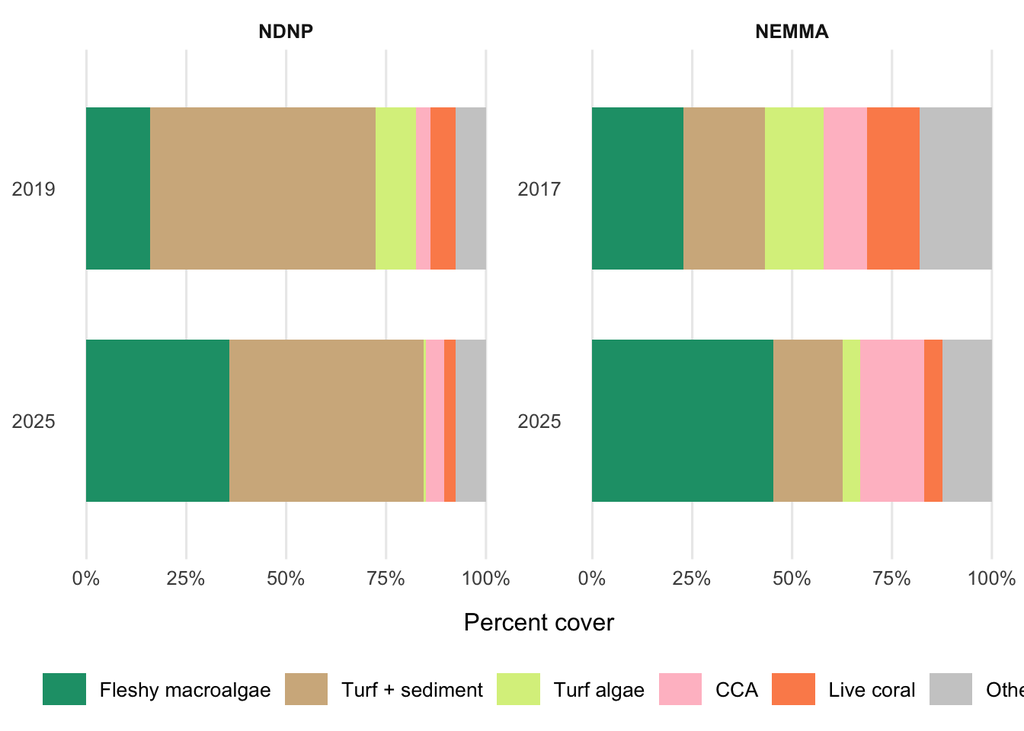

```r
benthic_barplot <- benthic_cover_year %>%
  filter(var %in% c(benthic_var)) %>%
  # create "other" category for plot
  mutate(var = if_else(var %in% c("cma", "peys", "ainv"),
                          "other",
                          var)) %>%
  # recalculate means with new "other" category
  group_by(year, zone, var) %>%
  summarise(mean = sum(mean),
            .groups = "drop") %>%
  # labels
  mutate(
    var = recode(
      var,
      lc    = "Live coral",
      cca   = "CCA",
      ta    = "Turf algae",
      tas   = "Turf + sediment",
      fma   = "Fleshy macroalgae",
      other = "Other"
    ),
    var = factor(
      var,
      levels = c(
        "Other",
        "Live coral",
        "CCA",
        "Turf algae",
        "Turf + sediment",
        "Fleshy macroalgae")),
    year = factor(year, levels = c(2025, 2019, 2017)))

ggplot(benthic_barplot,
       aes(x = mean,
           y = factor(year),
           fill = var)) +
  geom_col(width = 0.7) +
  facet_wrap(~zone,
             scales = "free_y") +
  scale_fill_manual(values = c(
    "Live coral" = "#fc8d59",
    "CCA" = "pink",
    "Turf algae" = "#d9ef8b",
    "Turf + sediment" = "tan",
    "Fleshy macroalgae" = "#1b9e77",
    "Other" = "gray80")) +
  scale_x_continuous(labels = scales::percent_format(accuracy = 1)) +
  labs(x = "Percent cover",
       y = NULL,
       fill = NULL) +
  guides(fill = guide_legend(
    nrow = 1,
    reverse = TRUE,
    byrow = TRUE)) +
  theme_minimal(base_size = 12) +
  theme(panel.grid.major.y = element_blank(),
        panel.grid.minor = element_blank(),
        strip.text = element_text(face = "bold"),
        axis.title.x = element_text(
          margin = margin(t = 12)),
        legend.position = "bottom",
        legend.text = element_text(size = 10),
        legend.key.width = unit(0.8, "cm"),
        legend.box = "horizontal")
```

```r
# ggsave(here(fig_dir, "benthic_sum.png"), width = 8, height = 5)
```

### Benthic delta

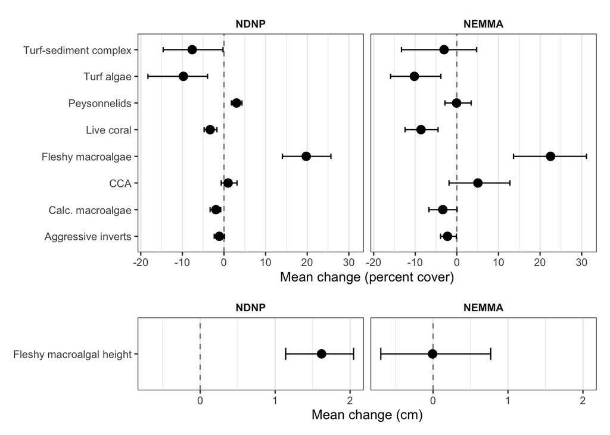

```r
p_delta_pc <- ggplot(sum_zone %>%
                       filter(metric == "benthic_cover",
                              var %in% benthic_var) %>%
                       mutate(delta_pct = delta * 100,
                              CI_low_pct = CI_low * 100,
                              CI_high_pct = CI_high * 100),
                     aes(x = delta_pct, y = var_pub)) +
  geom_vline(xintercept = 0,
             linetype = "dashed",
             color = "grey50") +
  geom_errorbarh(aes(xmin = CI_low_pct,
                     xmax = CI_high_pct),
                 height = 0.2) +
  geom_point(size = 3) +
  facet_wrap(~ zone) +
  labs(x = "Mean change (percent cover)",
       y = NULL) +
  theme_bw() +
  theme(strip.background = element_blank(),
        strip.text = element_text(face = "bold"),
        panel.grid.major.y = element_blank())


p_delta_fmah <- ggplot(sum_zone %>%
                         filter(var == "fma_height"),
                       aes(x = delta, y = var_pub)) +
  geom_vline(xintercept = 0,
             linetype = "dashed",
             color = "grey50") +
  geom_errorbarh(aes(xmin = CI_low,
                     xmax = CI_high),
                 height = 0.2) +
  geom_point(size = 3) +
  facet_wrap(~ zone) +
  labs(x = "Mean change (cm)",
       y = NULL) +
  theme_bw() +
  theme(strip.background = element_blank(),
        strip.text = element_text(face = "bold"),
        panel.grid.major.y = element_blank())

p_delta_pc / p_delta_fmah + plot_layout(heights = c(3, 1))
```

```r
ggsave(here(fig_dir, "benthic_delta_panel.png"), width = 6, height = 4)
```

### Fish biomass line

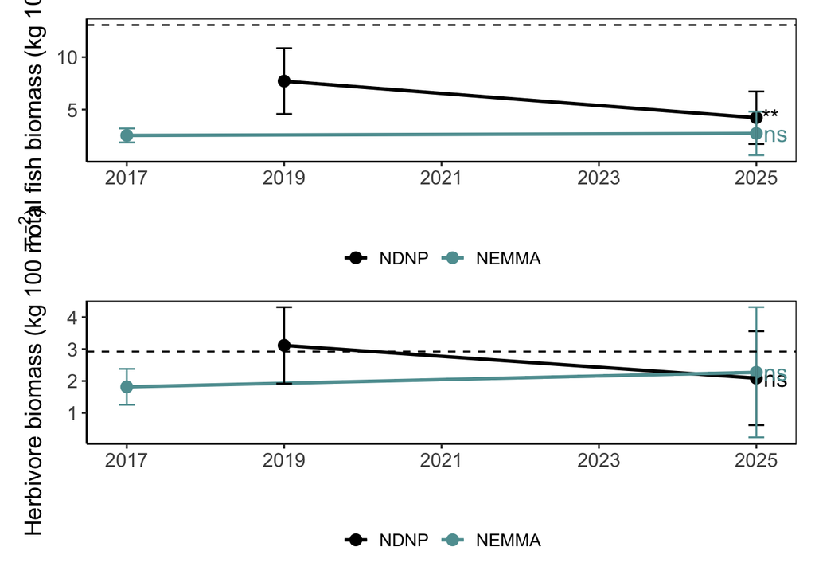

```r
make_lp_summary <- function(summary_df,
                            sig_df,
                            metric_name,
                            family_name,
                            ylab,
                            hline_value = NULL) {

  plot_df <- summary_df %>%
    filter(metric == metric_name,
           var == family_name) %>%
    group_by(zone, year) %>%
    summarise(
      mean = mean(value, na.rm = TRUE),
      sd   = sd(value, na.rm = TRUE),
      .groups = "drop"
    ) %>%
    mutate(year = as.numeric(year))

  sig_df_var <- sig_df %>%
    filter(metric == metric_name,
           var == family_name)

  plot_df <- plot_df %>%
    left_join(sig_df_var, by = "zone")

  p <- ggplot(plot_df,
              aes(x = year,
                  y = mean,
                  group = zone,
                  color = zone)) +
    geom_point(size = 3) +
    geom_line(size = 1) +
    scale_color_manual(values = c("black", "cadetblue")) +
    scale_x_continuous(breaks = seq(2017, 2025, by = 2),  # odd years from 2017 to 2025
                       labels = seq(2017, 2025, by = 2)) +
    geom_errorbar(aes(ymin = mean - sd,
          ymax = mean + sd),
      width = 0.2) +
    geom_text(data = plot_df %>% filter(year == max(year)),
      aes(label = p_label),
      hjust = -0.3,
      size = 5,
      show.legend = FALSE) +
    labs(x = "",
      y = ylab,
      color = NULL) +
    theme_pub() +
    theme(legend.position = "bottom")

  if (!is.null(hline_value)) {
    p <- p +
      geom_hline(
        yintercept = hline_value,
        linetype = "dashed",
        color = "black"
      )
  }

  return(p)
}

p_bm_tot <- make_lp_summary(
  summary_df = sum_site_yr,
  sig_df = sum_zone,
  metric_name = "fish_biomass",
  family_name = "total",
  ylab = expression("Total fish biomass (" * kg ~ 100 ~ m^{-2} * ")"),
  hline_value = 1306 / 100 # Karr et al 2015 - 1300 kg/ha - converting to g/100m2
)

p_bm_herb <- make_lp_summary(
  summary_df = sum_site_yr,
  sig_df = sum_zone,
  metric_name = "fish_biomass",
  family_name = "herbivores",
  ylab = expression("Herbivore biomass (" * kg ~ 100 ~ m^{-2} * ")"),
  hline_value = 29.2*100 / 1000 # Edwards et al 2014 - 29.2 g/m2 - converting to g/100m2
)

p_bm_tot / p_bm_herb + plot_layout(heights = c(10,10))
```

```r
ggsave(here(fig_dir, "fish_bm_change.png"), width = 6, height = 8)
```